# Homework 05

Improve the formatting of STAT 432 homework plots made in R or Python only when the user explicitly requests this skill. Do not apply it to other plots or without an explicit request.

Set a random seed before each simulation question and report it. You may use standard packages unless a question asks you to write the calculation yourself. Use equal neighbor weights throughout. Here $p$ counts the covariates used to measure distance; do not add an intercept column to a KNN predictor matrix. R and Python use different random-number generators, so their exact simulation results need not agree.

## Question 1: Estimate the bias and variance of KNN

In our previous homework, we used repeated simulations to study the behavior of linear regression estimators. We will now use the same idea for KNN. Consider the regression model

$$Y_i=f(\mathbf X_i)+\epsilon_i,
\qquad
f(\mathbf x)=0.5x_1+\sin(x_2)-0.3x_3^2,$$

where the three covariates are independent standard normal variables and $\epsilon_i\sim\mathcal N(0,0.1^2)$ independently of the covariates and other observations. Generate $n=400$ training observations. Our goal is to estimate the mean response at

$$\mathbf x_0=(0.5,0.7,1)^{\mathsf T}.$$

Use Euclidean distance and consider $k=1,3,5,\ldots,29$.

1. Calculate $f(\mathbf x_0)$. Generate one training dataset and obtain the KNN prediction at $\mathbf x_0$ for each value of $k$.

**Show the workflow**

```python
import numpy as np
import pandas as pd
from sklearn.neighbors import KNeighborsRegressor

seed = 153246
rng = np.random.default_rng(seed)
print(f"Question 1 seed: {seed}")

def f(x1, x2, x3):
    return 0.5 * x1 + np.sin(x2) - 0.3 * x3**2

x0 = pd.DataFrame({"x1": [0.5], "x2": [0.7], "x3": [1.0]})
f_x0 = f(0.5, 0.7, 1.0)
print(f"f(x0) = {f_x0:.6f}")

n = 400
features = ["x1", "x2", "x3"]
df = pd.DataFrame(rng.normal(size=(n, 3)), columns=features)
df["y"] = f(df["x1"], df["x2"], df["x3"]) + rng.normal(0, 0.1, n)

k_values = range(1, 30, 2)
predictions = []
for k in k_values:
    knn = KNeighborsRegressor(
        n_neighbors=k, weights="uniform", metric="euclidean"
    )
    knn.fit(df[features], df["y"])
    predictions.append(knn.predict(x0)[0])

results_1a = pd.DataFrame({"k": k_values, "KNN prediction": predictions})
results_1a
```

```
Question 1 seed: 153246
f(x0) = 0.594218
```

|  | k | KNN prediction |
| --- | --- | --- |
| 0 | 1 | 0.626570 |
| 1 | 3 | 0.511794 |
| 2 | 5 | 0.468028 |
| 3 | 7 | 0.484021 |
| 4 | 9 | 0.490666 |
| 5 | 11 | 0.517420 |
| 6 | 13 | 0.600213 |
| 7 | 15 | 0.560006 |
| 8 | 17 | 0.540577 |
| 9 | 19 | 0.566029 |
| 10 | 21 | 0.570123 |
| 11 | 23 | 0.576308 |
| 12 | 25 | 0.617589 |
| 13 | 27 | 0.630799 |
| 14 | 29 | 0.580717 |

2. Independently repeat the generation of the training covariates and responses 200 times. Within each repetition, use the same training data for every value of $k$. Store the predictions in a matrix with 200 rows and one column for each value of $k$. Use this matrix to estimate the bias, variance, and mean squared error of the estimated mean response. Use divisor 200 when calculating the empirical variance, and verify numerically that

$$\text{mean squared error}
=\text{squared bias}+\text{variance}.$$

Plot squared bias, variance, and mean squared error against $k$ in one figure. Explain the pattern and compare it with the bias-variance trade-off for ridge regression or lasso.

**Show the workflow**

```
sum of bias and variance = [0.04686828 0.02130629 0.01680957 0.0166933  0.01477467 0.01546027
 0.01526555 0.01574308 0.01771642 0.01847295 0.01825655 0.01870903
 0.01971579 0.02080825 0.02151148]
mse =  [0.04686828 0.02130629 0.01680957 0.0166933  0.01477467 0.01546027
 0.01526555 0.01574308 0.01771642 0.01847295 0.01825655 0.01870903
 0.01971579 0.02080825 0.02151148]
```

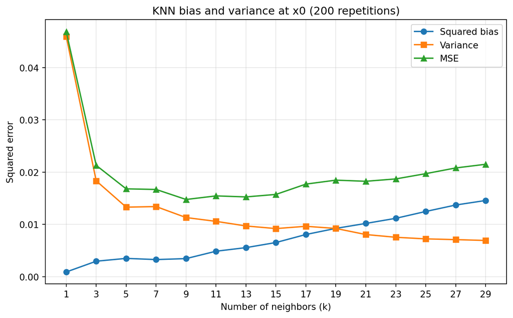

```python
n_repetitions = 200
prediction_matrix = np.empty((n_repetitions, len(k_values)))

for repetition in range(n_repetitions):
    df_rep = pd.DataFrame(rng.normal(size=(n, 3)), columns=features)
    df_rep["y"] = f(df_rep["x1"], df_rep["x2"], df_rep["x3"]) + rng.normal(0, 0.1, n)

    for column, k in enumerate(k_values):
        knn = KNeighborsRegressor(
            n_neighbors=k, weights="uniform", metric="euclidean"
        )
        knn.fit(df_rep[features], df_rep["y"])
        prediction_matrix[repetition, column] = knn.predict(x0)[0]

bias = prediction_matrix.mean(axis=0) - f_x0
squared_bias = bias**2
variance = prediction_matrix.var(axis=0, ddof=0)
mse = ((prediction_matrix - f_x0)**2).mean(axis=0)

results_1b = pd.DataFrame({
    "k": k_values,
    "Bias": bias,
    "Squared bias": squared_bias,
    "Variance": variance,
    "MSE": mse,
    "Squared bias + variance": squared_bias + variance,
    "Difference": mse - (squared_bias + variance),
})

print(f"sum of bias and variance =", squared_bias + variance)
print(f"mse = ", mse)

import matplotlib.pyplot as plt

fig, ax = plt.subplots(figsize=(8, 5))
ax.plot(k_values, squared_bias, marker="o", label="Squared bias")
ax.plot(k_values, variance, marker="s", label="Variance")
ax.plot(k_values, mse, marker="^", label="MSE")
ax.set(
    xlabel="Number of neighbors (k)",
    ylabel="Squared error",
    title="KNN bias and variance at x0 (200 repetitions)",
    xticks=list(k_values),
)
ax.legend()
ax.grid(alpha=0.3)
fig.tight_layout()
plt.show()
```

The variance decreases as k rises, because more neighbors are averaged and the result is less sensitive to the particular training sample. The squared bias increases, because observations farther from $x_0$ which has mean responses may differ from $f(x_0)$ is included. The mse decrease before increase is the result of bias-variance tradeoff. It dominated by changes in variance first then by bias. The bahavior is similar to ridge and lasso.

## Question 2: Compare KNN with lasso

Use the response model from Question 1, including the noise standard deviation $0.1$, but generate $p=30$ covariates. The response still depends only on the first three. Consider these two settings:

- **Setting 1:** all 30 covariates are independent standard normal variables.
- **Setting 2:** the covariates have a multivariate normal distribution with mean zero and covariance matrix $\boldsymbol\Sigma$, where

  $$\Sigma_{jj}=1,
  \qquad
  \Sigma_{jl}=0.8\quad\text{for }j\ne l.$$

In each setting, generate 400 training observations and 1,000 independent test observations. Fit 5NN using Euclidean distance on the supplied covariate scale. All covariates already have population variance one.

For lasso, use a linear model containing the 30 covariates and a separately fitted, unpenalized intercept. Follow the Week 4 objective,

$$L_\lambda(\boldsymbol\beta)
=\frac{1}{2n}\left\lVert
\widetilde{\mathbf y}-\mathbf X\boldsymbol\beta
\right\rVert_2^2
+\lambda\lVert\boldsymbol\beta\rVert_1,$$

where $\mathbf X\in\mathbb R^{n\times30}$ contains the centered and standardized covariates and $\widetilde{\mathbf y}$ is the centered training response. Select the penalty by ten-fold cross-validation over 41 logarithmically spaced values from $10^{-4}$ to $1$. Estimate all means and scales using only the training portion of each fold, with divisor equal to that portion’s sample size. After selecting the penalty, refit on all training observations and apply the fitted transformations unchanged to the test observations. Do not add nonlinear terms to the lasso model.

1. Fit both methods in each setting. Use the same training and test data for the two methods within a setting. Report their test MSE values in one table, together with the selected lasso penalty and the number of nonzero lasso slopes. You only need to generate one dataset for each setting; repeated simulations are not required.

**Show the workflow**

```python
from sklearn.linear_model import Lasso
from sklearn.model_selection import KFold
from sklearn.metrics import mean_squared_error

seed = 153247
rng = np.random.default_rng(seed)
print(f"Question 2 seed: {seed}")

n_train, n_test, p = 400, 1000, 30
lambdas = np.logspace(-4, 0, 41)
folds = list(KFold(n_splits=10, shuffle=True, random_state=seed)
             .split(np.arange(n_train)))

def generate_data(n, covariance):
    X = rng.multivariate_normal(np.zeros(p), covariance, size=n)
    y = (0.5 * X[:, 0] + np.sin(X[:, 1]) - 0.3 * X[:, 2]**2
         + rng.normal(0, 0.1, n))
    return X, y

covariances = {
    "Independent": np.eye(p),
    "Correlated (rho = 0.8)": 0.8 * np.ones((p, p)) + 0.2 * np.eye(p),
}
rows = []
cv_results = {}

for setting, covariance in covariances.items():
    X_train, y_train = generate_data(n_train, covariance)
    X_test, y_test = generate_data(n_test, covariance)

    knn = KNeighborsRegressor(
        n_neighbors=5, weights="uniform", metric="euclidean"
    )
    knn.fit(X_train, y_train)
    knn_mse = mean_squared_error(y_test, knn.predict(X_test))

    fold_mse = np.empty((len(lambdas), len(folds)))
    for fold, (fit_index, validation_index) in enumerate(folds):
        X_fit, X_validation = X_train[fit_index], X_train[validation_index]
        y_fit, y_validation = y_train[fit_index], y_train[validation_index]

        x_mean = X_fit.mean(axis=0)
        x_scale = X_fit.std(axis=0, ddof=0)
        X_fit_std = (X_fit - x_mean) / x_scale
        X_validation_std = (X_validation - x_mean) / x_scale
        y_mean = y_fit.mean()

        for j, lam in enumerate(lambdas):
            lasso = Lasso(alpha=lam, fit_intercept=False,
                          max_iter=10000, tol=1e-8)
            lasso.fit(X_fit_std, y_fit - y_mean)
            prediction = y_mean + lasso.predict(X_validation_std)
            fold_mse[j, fold] = mean_squared_error(y_validation, prediction)

    cv_mse = fold_mse.mean(axis=1)
    best_lambda = lambdas[np.argmin(cv_mse)]
    cv_results[setting] = pd.DataFrame({"lambda": lambdas, "CV MSE": cv_mse})

    x_mean = X_train.mean(axis=0)
    x_scale = X_train.std(axis=0, ddof=0)
    y_mean = y_train.mean()
    lasso = Lasso(alpha=best_lambda, fit_intercept=False,
                  max_iter=10000, tol=1e-8)
    lasso.fit((X_train - x_mean) / x_scale, y_train - y_mean)
    prediction = y_mean + lasso.predict((X_test - x_mean) / x_scale)

    rows.append({
        "Setting": setting,
        "5NN test MSE": knn_mse,
        "Lasso test MSE": mean_squared_error(y_test, prediction),
        "Selected lambda": best_lambda,
        "Nonzero lasso slopes": np.count_nonzero(lasso.coef_),
    })

results_2a = pd.DataFrame(rows)
print(results_2a.to_string(index=False))
```

```
Question 2 seed: 153247
               Setting  5NN test MSE  Lasso test MSE  Selected lambda  Nonzero lasso slopes
           Independent      0.604535        0.275845         0.031623                     5
Correlated (rho = 0.8)      0.192056        0.268038         0.031623                     7
```

2. Compare the results between the two settings. Explain how correlation can change the usefulness of Euclidean neighborhoods, and why lasso does not use all covariates in the same way as KNN.

There is a big fall on 5NN MSE result when the covariates are correlated and small improvement on Lasso MSE. Correlation improve the usefulness of Euclidean neighborhoods, because more correlated covatiates carry more shared information and makes distances more informative. However, the 27 irrelevant variables contribute noise to Euclidean distances in independent covariates making the large test MSE. Lasso can set coefficients to zero, whereas KNN includes every supplied covariate in its distance calculation.

3. The response model contains $\sin(X_2)$ and $X_3^2$, but the lasso fit uses only linear terms. Explain how this difference affects the comparison. Would the results justify a general claim that correlation always helps KNN, or that one method is always better? Explain why.

This will lead to a mismodel when using lasso, which makes MSE for lasso bigger. The results cannot justify correlation always helps KNN, because its effect depends on the correlation structure and how it relates to the response. The results do not justify one method is always better when there is correlation, becuase the performance for lasson in correlated case is influenced by only linear terms in its model, and one dataset per setting is insufficient to establish a general performance ranking.

## Question 3: Observed dimension and latent dimension

The lecture’s handwritten digit example shows that KNN can work with many measured covariates. We will use a simulation to investigate why the structure of those covariates matters.

Let $p=100$ be the number of observed covariates and let $m$ be the number of latent variables. For each observation, generate

$$\mathbf X_i=\mathbf A\mathbf Z_i+\boldsymbol\eta_i,
\qquad
Y_i=Z_{i1}+Z_{i2}+\epsilon_i,$$

where $\mathbf A\in\mathbb R^{100\times m}$ has independent entries from Uniform$[-2,2]$. The entries of $\mathbf Z_i\in\mathbb R^m$ and $\boldsymbol\eta_i\in\mathbb R^{100}$, and the scalar $\epsilon_i$, are independent standard normal variables, also independent of $\mathbf A$. Generate $\mathbf A$ once and use it for all training and test observations in that dataset.

Compare $m=3$ and $m=30$. In each setting, generate 200 training observations and 200 independent test observations. Fit KNN using only the 100 observed covariates in $\mathbf X$, with Euclidean distance on their generated scale. The latent variables in $\mathbf Z$ are used to generate the data but are not available to the fitted model. Consider $k=2,10,18,\ldots,82$.

1. Generate one dataset for each value of $m$. Fit KNN for every value of $k$ and calculate test MSE. Within a setting, use the same training and test observations for all values of $k$.

**Show the workflow**

```python
seed = 153248
rng = np.random.default_rng(seed)
print(f"Question 3 seed: {seed}")

features_3a = [f"x{j}" for j in range(1, 101)]

def generate_latent_data(n, A, rng):
    Z = rng.normal(size=(n, A.shape[1]))
    eta = rng.normal(size=(n, 100))
    epsilon = rng.normal(size=n)
    X = Z @ A.T + eta
    y = Z[:, 0] + Z[:, 1] + epsilon
    data = pd.DataFrame(X, columns=features_3a)
    data["y"] = y
    return data

A_m3 = rng.uniform(-2, 2, size=(100, 3))
train_m3 = generate_latent_data(200, A_m3, rng)
test_m3 = generate_latent_data(200, A_m3, rng)

A_m30 = rng.uniform(-2, 2, size=(100, 30))
train_m30 = generate_latent_data(200, A_m30, rng)
test_m30 = generate_latent_data(200, A_m30, rng)

k_values_3a = range(2, 83, 8)
rows_3a = []
for m, train, test in [(3, train_m3, test_m3), (30, train_m30, test_m30)]:
    for k in k_values_3a:
        knn = KNeighborsRegressor(n_neighbors=k, weights="uniform", metric="euclidean")
        knn.fit(train[features_3a], train["y"])
        predictions = knn.predict(test[features_3a])
        rows_3a.append({"m": m, "k": k, "Test MSE": mean_squared_error(test["y"], predictions)})

results_3a = pd.DataFrame(rows_3a)
print(results_3a.to_string(index=False))
```

```
Question 3 seed: 153248
 m  k  Test MSE
 3  2  1.654795
 3 10  1.205875
 3 18  1.342105
 3 26  1.441427
 3 34  1.491547
 3 42  1.575049
 3 50  1.655371
 3 58  1.722632
 3 66  1.772107
 3 74  1.858260
 3 82  1.919183
30  2  1.966982
30 10  1.819458
30 18  1.808056
30 26  1.850661
30 34  1.875217
30 42  1.896176
30 50  1.906821
30 58  1.908114
30 66  1.947420
30 74  1.981694
30 82  1.994768
```

2. Repeat the complete experiment 50 times, generating a new $\mathbf A$ and new observations in each repetition. Plot average test MSE against $k$, with one curve for each value of $m$. These curves compare the specified choices of $k$ in a controlled simulation; they are not a cross-validation procedure for selecting a final model.

**Show the workflow**

```
Repetition results shape: (550, 3)
  mse_3m  mse_30m  k
1.674048 3.120383  2
1.276371 2.353122 10
1.290334 2.347849 18
1.334885 2.376485 26
1.389988 2.406738 34
1.443598 2.439778 42
1.498822 2.469217 50
1.559125 2.503935 58
1.617583 2.535806 66
1.676801 2.565777 74
1.734794 2.596574 82
```

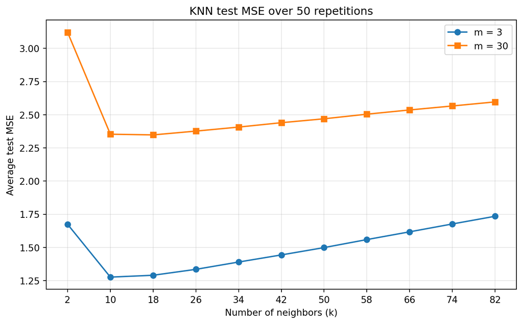

```python
rows_3b = []
for repetition in range(50):
    mse_by_m = {}
    for m in (3, 30):
        A = rng.uniform(-2, 2, size=(100, m))
        train = generate_latent_data(200, A, rng)
        test = generate_latent_data(200, A, rng)
        mse_by_m[m] = []
        for k in k_values_3a:
            knn = KNeighborsRegressor(n_neighbors=k, weights="uniform", metric="euclidean")
            knn.fit(train[features_3a], train["y"])
            predictions = knn.predict(test[features_3a])
            mse_by_m[m].append(mean_squared_error(test["y"], predictions))

    for j, k in enumerate(k_values_3a):
        rows_3b.append({"mse_3m": mse_by_m[3][j], "mse_30m": mse_by_m[30][j], "k": k})

results_3b = pd.DataFrame(rows_3b, columns=["mse_3m", "mse_30m", "k"])
average_mse_3b = (results_3b.groupby("k", as_index=False)[["mse_3m", "mse_30m"]]
                  .mean()[["mse_3m", "mse_30m", "k"]])
print(f"Repetition results shape: {results_3b.shape}")
print(average_mse_3b.to_string(index=False))

fig, ax = plt.subplots(figsize=(8, 5))
ax.plot(average_mse_3b["k"], average_mse_3b["mse_3m"], marker="o", label="m = 3")
ax.plot(average_mse_3b["k"], average_mse_3b["mse_30m"], marker="s", label="m = 30")
ax.set(xlabel="Number of neighbors (k)", ylabel="Average test MSE",
       title="KNN test MSE over 50 repetitions", xticks=list(k_values_3a))
ax.legend()
ax.grid(alpha=0.3)
fig.tight_layout()
plt.show()
```

3. Both settings have 100 observed covariates, and the response depends on only two latent variables. Explain why their KNN performance can still differ. What role does the noise $\boldsymbol\eta_i$ play, and why are the observed data not confined exactly to an $m$-dimensional linear space?

For m = 30, 28 latent directions affect X but do not directly affect Y. KNN find closed k points with respect to variation from all these directions, so points closes in X may be less similar in Y for m = 30, which leads to highere MSE for m = 30 compared to m = 3. $AZ_i$ create a column space of A with m dimensions, and adding $\eta_i$ adds noise to this column space to make points away from their original position, which may lead to the deviation from m-dimensional linear space.

## Question 4: Classify handwritten digits

Use `zip.train` and `zip.test` from the R package `ElemStatLearn`, as in the lecture. The package has been retired from the active CRAN repository. If needed, install the [archived package](https://cran.r-project.org/src/contrib/Archive/ElemStatLearn/ElemStatLearn_2015.6.26.2.tar.gz) into your usual R library, then load the two datasets. Python users can use the course copies of the same [training data](https://teazrq.github.io/stat432rpy/data/knn/zip-train.csv.gz) and [test data](https://teazrq.github.io/stat432rpy/data/knn/zip-test.csv.gz). These compressed CSV files have no headers and are included in the homework ZIP under `data/knn`. Run the Python code from the folder containing `data`.

Each image has $16\times16=256$ pixel values. The first column is the digit label and the remaining columns are the pixel values. Use the first 1,000 rows of `zip.train` and the first 500 rows of `zip.test`. Use the original pixel values without standardization, and do not include the digit label in a distance calculation.

For a test image $\mathbf x_0$ and a training image $\mathbf x_i$, the two distances are

$$d_E(\mathbf x_0,\mathbf x_i)
=\sqrt{\sum_{j=1}^{256}(x_{0j}-x_{ij})^2},
\qquad
d_M(\mathbf x_0,\mathbf x_i)
=\sum_{j=1}^{256}|x_{0j}-x_{ij}|.$$

1. Write a 5NN classification function that allows either Euclidean or Manhattan distance. For each test image, calculate its distances to the training images directly, find the five nearest, and return the most frequent digit label. Break distance ties by the smaller training row number and voting ties by the smallest digit. Do not use a built-in distance or KNN function for this part.

**Show the workflow**

```python
train_4 = pd.read_csv("data/knn/zip-train.csv", header=None).iloc[:1000]
test_4 = pd.read_csv("data/knn/zip-test.csv", header=None).iloc[:500]

train_digits = train_4.iloc[:, 0].to_numpy(dtype=int)
train_images = train_4.iloc[:, 1:].to_numpy()
test_images = test_4.iloc[:, 1:].to_numpy()

def classify_5nn(test_images, train_images, train_digits, metric="euclidean"):
    if metric not in ("euclidean", "manhattan"):
        raise ValueError("metric must be 'euclidean' or 'manhattan'")

    predictions = np.empty(len(test_images), dtype=int)
    for test_row in range(len(test_images)):
        distances = []
        for train_row in range(len(train_images)):
            difference = test_images[test_row] - train_images[train_row]
            if metric == "euclidean":
                value = np.sqrt(np.sum(difference**2))
            else:
                value = np.sum(np.abs(difference))
            distances.append(value)

        distance = pd.DataFrame({
            "distance": distances,
            "digit": train_digits,
            "row": np.arange(len(train_images)),
        })
        nearest = distance.nsmallest(5, ["distance", "row"])
        votes = nearest["digit"].value_counts()
        predictions[test_row] = votes[votes == votes.max()].index.min()

    return predictions

pred_euclidean_4 = classify_5nn(test_images, train_images, train_digits, "euclidean")
```

2. Apply the classifier to all 500 test images using each distance. For each fit, report the test classification error and a $10\times10$ confusion matrix, with rows representing predicted digits and columns representing true digits. Keep all digit labels from 0 through 9 in the matrix, including any with a zero count. Which digits are most often confused with one another?

**Show the workflow**

```python
test_digits = test_4.iloc[:, 0].to_numpy(dtype=int)
pred_manhattan_4 = classify_5nn(test_images, train_images, train_digits, "manhattan")

errors_4b = {}
confusions_4b = {}
for metric, predictions in [("Euclidean", pred_euclidean_4),
                            ("Manhattan", pred_manhattan_4)]:
    errors_4b[metric] = np.mean(predictions != test_digits)
    confusion = pd.crosstab(
        pd.Series(predictions, name="Predicted"),
        pd.Series(test_digits, name="True"),
    ).reindex(index=range(10), columns=range(10), fill_value=0)
    confusions_4b[metric] = confusion

    pairs = [(a, b, int(confusion.loc[a, b] + confusion.loc[b, a]))
             for a in range(10) for b in range(a + 1, 10)]
    pairs.sort(key=lambda pair: (-pair[2], pair[0], pair[1]))

    print(f"{metric} test error: {errors_4b[metric]:.3f}")
    print(confusion.to_string())
    print("Most confused digit pairs (both directions):")
    for a, b, count in pairs[:3]:
        print(f"  {a} and {b}: {count} images")
    print()
```

```
Euclidean test error: 0.122
True         0   1   2   3   4   5   6   7   8   9
Predicted
0          118   0   7   1   0   4   2   0   2   0
1            0  66   0   0   2   0   0   0   0   1
2            0   0  39   1   0   0   2   0   0   1
3            0   0   0  23   0   4   0   0   2   0
4            0   0   1   0  27   1   1   1   0   1
5            0   0   0   1   0  13   0   0   0   0
6            0   2   0   0   0   1  41   0   2   0
7            0   0   0   0   1   1   0  34   0   4
8            0   0   3   2   0   2   0   0  37   0
9            1   0   0   1   4   0   0   1   1  41
Most confused digit pairs (both directions):
  0 and 2: 7 images
```

[output cut: 20 more lines]

3. For Euclidean distance, display three incorrectly classified test images, together with their true and predicted labels. Comment on whether the mistakes are visually understandable. Compare the overall results of the two distance measures. Can they have similar total error while making mistakes on different images? Use your predictions to support your answer.

**Show the workflow**

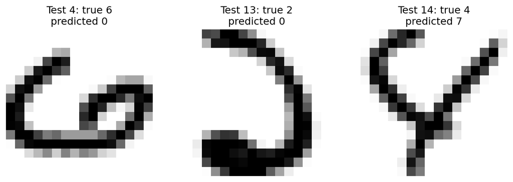

```
Euclidean errors: 61 (12.2%)
Manhattan errors: 69 (13.8%)
Wrong under both distances: 58
Wrong only under Euclidean: 3
Wrong only under Manhattan: 11
```

```python
euclidean_wrong = pred_euclidean_4 != test_digits
manhattan_wrong = pred_manhattan_4 != test_digits
misclassified_indices = np.flatnonzero(euclidean_wrong)[:3]

fig, axes = plt.subplots(1, 3, figsize=(9, 3))
for ax, index in zip(axes, misclassified_indices):
    ax.imshow(test_images[index].reshape(16, 16), cmap="gray_r", vmin=-1, vmax=1)
    ax.set_title(f"Test {index + 1}: true {test_digits[index]}\npredicted {pred_euclidean_4[index]}")
    ax.axis("off")
fig.tight_layout()
plt.show()

both_wrong = np.sum(euclidean_wrong & manhattan_wrong)
only_euclidean_wrong = np.sum(euclidean_wrong & ~manhattan_wrong)
only_manhattan_wrong = np.sum(~euclidean_wrong & manhattan_wrong)

print(f"Euclidean errors: {euclidean_wrong.sum()} ({errors_4b['Euclidean']:.1%})")
print(f"Manhattan errors: {manhattan_wrong.sum()} ({errors_4b['Manhattan']:.1%})")
print(f"Wrong under both distances: {both_wrong}")
print(f"Wrong only under Euclidean: {only_euclidean_wrong}")
print(f"Wrong only under Manhattan: {only_manhattan_wrong}")
```

The first two are understandable, but the last one is not. They share large amout of errors. Euclidean seems like perform better than Manhattan.

## Question 5: Create a plot-formatting skill

Create a short `SKILL.md` file for improving the formatting of STAT 432 homework plots. You may use AI to help write it.

1. Include a title, a description, and a few formatting rules. The description should limit the skill to STAT 432 homework plot improvements and require an explicit request to use it. Your rules should address margins, titles, axes, labels, colors, and sizes for plots produced in R or Python. Keep them portable: do not refer to specific homework questions.
2. Ask your agent to install the skill. Explicitly call it to improve the plot from Question 1, then compare the original and revised versions. Do you like the changes? You may revise the skill and test it a couple more times, or uninstall it if it remains unhelpful.

3. Append your final `SKILL.md` content to your submission and briefly explain your choices and experience.

My choices are mainly on improve the format of plot to make reader understand it easier. The skill make plot easier and more stable as I do not need to specify my request on graph everytime.

Final `SKILL.md` content:

```markdown
---

name: stat432-plot-formatting
description: Improve the formatting of STAT 432 homework plots made in R or Python only when the user explicitly requests this skill. Do not apply it to other plots or without an explicit request.
---

# STAT 432 Plot Formatting

Improve readability while preserving the plot's data, calculations, and intended comparison.

- **Margins:** Leave enough space for titles, tick labels, legends, and captions; prevent clipping and avoid excessive empty space.
- **Titles:** Use a short, informative title that identifies what is plotted. Keep subtitles only when they add needed context.
- **Axes:** Choose sensible limits and tick spacing; show the relevant range without distorting comparisons.
- **Labels:** Name both axes clearly, include units when applicable, and make legend labels match the plotted quantities.
- **Colors:** Use a small, consistent, high-contrast palette that remains distinguishable in grayscale when practical. Do not rely on color alone to distinguish series.
- **Sizes:** Set figure, text, line, and marker sizes so the plot remains legible in a homework document and after export.

Apply these rules using the plotting tools already used in the R or Python code. Keep the final plot uncluttered.
```